# boston_housing_data

Scikit.learn(Pythonの機械学習ライブラリ)に入っているベンチマークデータ「Boston housing」（ボストンの各地区の住宅価格のデータ）を扱う。

Step 1. データの読み込み

```python
import os
import pandas as pd
from sklearn.datasets import load_boston
boston = load_boston()
boston = pd.DataFrame(boston.data, columns=boston.feature_names)
```

Step 2. データの確認

```python
boston.head() %データの先頭の5行を表示する（各行はひとつの地区に対応）
```

|  | CRIM | ZN | INDUS | CHAS | NOX | RM | AGE | DIS | RAD | TAX | PTRATIO | B | LSTAT |
| --- | --- | --- | --- | --- | --- | --- | --- | --- | --- | --- | --- | --- | --- |
| 0 | 0.00632 | 18.0 | 2.31 | 0.0 | 0.538 | 6.575 | 65.2 | 4.0900 | 1.0 | 296.0 | 15.3 | 396.90 | 4.98 |
| 1 | 0.02731 | 0.0 | 7.07 | 0.0 | 0.469 | 6.421 | 78.9 | 4.9671 | 2.0 | 242.0 | 17.8 | 396.90 | 9.14 |
| 2 | 0.02729 | 0.0 | 7.07 | 0.0 | 0.469 | 7.185 | 61.1 | 4.9671 | 2.0 | 242.0 | 17.8 | 392.83 | 4.03 |
| 3 | 0.03237 | 0.0 | 2.18 | 0.0 | 0.458 | 6.998 | 45.8 | 6.0622 | 3.0 | 222.0 | 18.7 | 394.63 | 2.94 |
| 4 | 0.06905 | 0.0 | 2.18 | 0.0 | 0.458 | 7.147 | 54.2 | 6.0622 | 3.0 | 222.0 | 18.7 | 396.90 | 5.33 |

各列（変数）の意味は以下のとおり（https://archive.ics.uci.edu/ml/machine-learning-databases/housing/housing.names）

1. CRIM per capita crime rate by town
2. ZN proportion of residential land zoned for lots over 25,000 sq.ft.
3. INDUS proportion of non-retail business acres per town
4. CHAS Charles River dummy variable (= 1 if tract bounds river; 0 otherwise)
5. NOX nitric oxides concentration (parts per 10 million)
6. RM average number of rooms per dwelling
7. AGE proportion of owner-occupied units built prior to 1940
8. DIS weighted distances to five Boston employment centres
9. RAD index of accessibility to radial highways
10. TAX full-value property-tax rate per \$10,000
11. PTRATIO pupil-teacher ratio by town
12. B 1000(Bk - 0.63)^2 where Bk is the proportion of blacks by town
13. LSTAT % lower status of the population
14. MEDV Median value of owner-occupied homes in $1000's 注：MEDVは住宅価格の中央値で、boston.targetに入っている

Step 3. ヒストグラムの描画

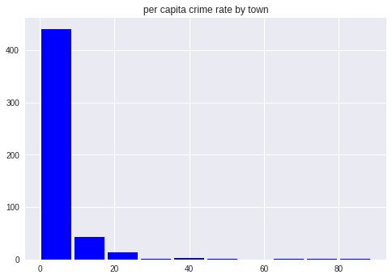

```python
import matplotlib.pyplot as plt #matplot: グラフ作成ライブラリ
plt.title("per capita crime rate by town") #グラフのタイトルを設定（日本語は表示不可）
plt.hist(boston["CRIM"], color = "blue", rwidth = 0.9) #XのCRIMのヒストグラムを生成
plt.show() #生成したヒストグラムを表示
```

Step 4. 散布図（2変数）の描画

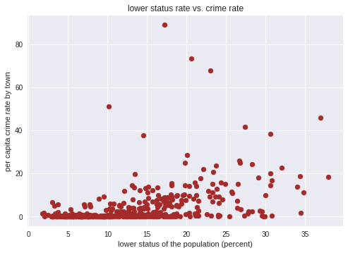

```python
plt.title("lower status rate vs. crime rate") #グラフのタイトルを設定（日本語は表示不可）
plt.xlabel("lower status of the population (percent)") #横軸にラベルを設定
plt.ylabel("per capita crime rate by town") #縦軸にラベルを設定
plt.scatter(x = boston["LSTAT"], y = boston["CRIM"], marker = "o", color= "brown") #散布図を生成
plt.show() #生成した散布図を表示
```